# Course Project ML

Hazem Haffouz

2024-01-02

# Leveraging Accelerometer Data to Predict Exercise Quality: A Machine Learning Approach”

## Introduction

This project aims to harness accelerometer data from devices like Jawbone Up, Nike FuelBand, and Fitbit to predict the manner in which exercises are performed. Utilizing data collected from accelerometers on the belt, forearm, arm, and dumbbell of participants, the project endeavors to classify barbell lifts into one of five categories, representing the quality of the exercise performed. This report outlines the methodology adopted, from exploratory data analysis (EDA) through to predictive modeling, culminating in the application of a Random Forest model to predict exercise quality in test cases.

```r
# Load necessary libraries
library(caret)
library(dplyr)
```

```r
library(ggplot2)
library(randomForest)
library(rpart)
library(rattle)
library(psych)
# Data Loading
training_url <- "https://d396qusza40orc.cloudfront.net/predmachlearn/pml-training.csv"
testing_url <- "https://d396qusza40orc.cloudfront.net/predmachlearn/pml-testing.csv"
training_data <- read.csv(training_url, na.strings=c("NA","#DIV/0!", ""))
testing_data <- read.csv(testing_url, na.strings=c("NA","#DIV/0!", ""))
```

## Exploratory Data Analysis (EDA)

```r
# Exploratory Data Analysis
summary(training_data[1:5])
```

```
##        X          user_name         raw_timestamp_part_1 raw_timestamp_part_2
##  Min.   :    1   Length:19622       Min.   :1.322e+09    Min.   :   294
##  1st Qu.: 4906   Class :character   1st Qu.:1.323e+09    1st Qu.:252912
##  Median : 9812   Mode  :character   Median :1.323e+09    Median :496380
##  Mean   : 9812                      Mean   :1.323e+09    Mean   :500656
##  3rd Qu.:14717                      3rd Qu.:1.323e+09    3rd Qu.:751891
##  Max.   :19622                      Max.   :1.323e+09    Max.   :998801
##  cvtd_timestamp
##  Length:19622
##  Class :character
##  Mode  :character
##
##
##
```

```r
describe(training_data[1:5])
```

|  | vars | n | mean | sd | median | trimmed | mad | min | max | range | skew | kurtosis | se |
| --- | --- | --- | --- | --- | --- | --- | --- | --- | --- | --- | --- | --- | --- |
| X | 1 | 19622 | 9.811500e+03 | 5.664528e+03 | 9811.5 | 9.811500e+03 | 7272.8943 | 1 | 19622 | 19621 | 0.000000000 | -1.200183 | 4.043822e+01 |
| user_name* | 2 | 19622 | 3.346957e+00 | 1.696717e+00 | 3.0 | 3.308702e+00 | 2.9652 | 1 | 6 | 5 | 0.071926402 | -1.255805 | 1.211261e-02 |
| raw_timestamp_part_1 | 3 | 19622 | 1.322827e+09 | 2.049277e+05 | 1322832920.0 | 1.322836e+09 | 237001.0230 | 1322489605 | 1323095081 | 605476 | -0.161529405 | -1.012394 | 1.462948e+03 |
| raw_timestamp_part_2 | 4 | 19622 | 5.006561e+05 | 2.882229e+05 | 496380.0 | 5.007597e+05 | 367764.8604 | 294 | 998801 | 998507 | 0.002336908 | -1.186941 | 2.057580e+03 |
| cvtd_timestamp* | 5 | 19622 | 1.097533e+01 | 5.754938e+00 | 11.0 | 1.100624e+01 | 7.4130 | 1 | 20 | 19 | -0.054605853 | -1.261259 | 4.108365e-02 |

```r
sum(is.null(training_data))
```

```
## [1] 0
```

```r
sum(is.na(training_data))
```

```
## [1] 1925102
```

```r
head(unique(training_data$columnName))
```

```r
summary(testing_data[1:5])
```

```
##        X          user_name         raw_timestamp_part_1 raw_timestamp_part_2
##  Min.   : 1.00   Length:20          Min.   :1.322e+09    Min.   : 36553
##  1st Qu.: 5.75   Class :character   1st Qu.:1.323e+09    1st Qu.:268655
##  Median :10.50   Mode  :character   Median :1.323e+09    Median :530706
##  Mean   :10.50                      Mean   :1.323e+09    Mean   :512167
##  3rd Qu.:15.25                      3rd Qu.:1.323e+09    3rd Qu.:787738
##  Max.   :20.00                      Max.   :1.323e+09    Max.   :920315
##  cvtd_timestamp
##  Length:20
##  Class :character
##  Mode  :character
##
##
##
```

```r
describe(testing_data[1:5])
```

|  | vars | n | mean | sd | median | trimmed | mad | min | max | range | skew | kurtosis | se |
| --- | --- | --- | --- | --- | --- | --- | --- | --- | --- | --- | --- | --- | --- |
| X | 1 | 20 | 10.5 | 5.916080e+00 | 10.5 | 1.050000e+01 | 7.4130 | 1 | 20 | 19 | 0.0000000 | -1.3809286 | 1.322876e+00 |
| user_name* | 2 | 20 | 4.2 | 1.472556e+00 | 5.0 | 4.312500e+00 | 1.4826 | 1 | 6 | 5 | -0.7027606 | -0.7458342 | 3.292735e-01 |
| raw_timestamp_part_1 | 3 | 20 | 1322777592.3 | 2.305603e+05 | 1322673138.5 | 1.322774e+09 | 258053.2017 | 1322489635 | 1323095002 | 605367 | 0.3191682 | -1.4880407 | 5.155485e+04 |
| raw_timestamp_part_2 | 4 | 20 | 512167.4 | 3.030681e+05 | 530705.5 | 5.197185e+05 | 394438.3170 | 36553 | 920315 | 883762 | -0.1446810 | -1.5189959 | 6.776809e+04 |
| cvtd_timestamp* | 5 | 20 | 6.8 | 3.365459e+00 | 7.0 | 6.937500e+00 | 4.4478 | 1 | 11 | 10 | -0.1819601 | -1.5386711 | 7.525396e-01 |

```r
sum(is.null(testing_data))
```

```
## [1] 0
```

```r
sum(is.na(testing_data))
```

```
## [1] 2000
```

```r
head(unique(testing_data$columnName))
```

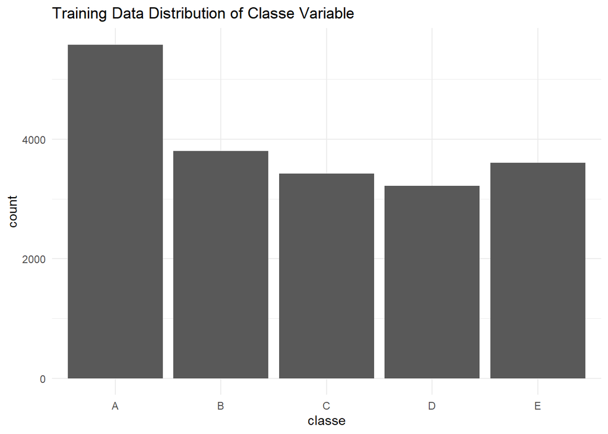

```r
ggplot(training_data, aes(classe)) + geom_bar() + theme_minimal() + labs(title="Training Data Distribution of Classe Variable")
```

## Data Processing Summary

Data preprocessing involved several crucial steps to prepare the data for modeling. Columns with excessive missing values were removed, ensuring data quality and integrity. Irrelevant columns, particularly the first seven, were discarded to focus on more pertinent features. The transformation of categorical variables into factors and the standardization of numerical columns were also integral to the preprocessing phase. This process ensured a consistent and analytically suitable dataset for training machine learning models.

```r
# Removing columns with too many missing values
threshold <- 0.6 * nrow(training_data)
training_data <- training_data[, colSums(is.na(training_data)) < threshold]
testing_data <- testing_data[, colnames(testing_data) %in% colnames(training_data)]

# Removing irrelevant columns (first 7 columns in this case)
training_data <- select(training_data, -(1:7))
testing_data <- select(testing_data, -(1:7))

# Converting categorical variables to factors
training_data <- mutate_if(training_data, is.character, as.factor)
testing_data <- mutate_if(testing_data, is.character, as.factor)

# Standardizing numerical columns
num_cols <- sapply(training_data, is.numeric)
preProcValues <- preProcess(training_data[, num_cols], method = c("center", "scale"))
training_data[, num_cols] <- predict(preProcValues, training_data[, num_cols])
testing_data[, num_cols] <- predict(preProcValues, testing_data[, num_cols])
```

## Data Modeling

```r
# Splitting the dataset into training and testing subsets
set.seed(123)
splitIndex <- createDataPartition(training_data$classe, p = 0.75, list = FALSE)
training_subset <- training_data[splitIndex, ]
testing_subset <- training_data[-splitIndex, ]
```

```r
# Decision Tree Model
fitControl <- trainControl(method = "cv", number = 5)
decisionTreeModel <- train(classe ~ ., data = training_subset, method = "rpart", trControl = fitControl)
```

```r
# Random Forest Model
randomForestModel <- randomForest(classe ~ ., data = training_subset)
```

```r
# Printing model summaries
print(decisionTreeModel)
```

```
## CART
##
## 14718 samples
##    52 predictor
##     5 classes: 'A', 'B', 'C', 'D', 'E'
##
## No pre-processing
## Resampling: Cross-Validated (5 fold)
## Summary of sample sizes: 11774, 11775, 11774, 11775, 11774
## Resampling results across tuning parameters:
##
##   cp          Accuracy   Kappa
##   0.03598215  0.5016312  0.34888168
##   0.05949555  0.4411591  0.25097067
##   0.11497199  0.3489572  0.09871325
##
## Accuracy was used to select the optimal model using the largest value.
## The final value used for the model was cp = 0.03598215.
```

```r
print(randomForestModel)
```

```
##
## Call:
##  randomForest(formula = classe ~ ., data = training_subset)
##                Type of random forest: classification
##                      Number of trees: 500
## No. of variables tried at each split: 7
##
##         OOB estimate of  error rate: 0.52%
## Confusion matrix:
##      A    B    C    D    E class.error
## A 4180    3    1    0    1 0.001194743
## B    9 2832    7    0    0 0.005617978
## C    0    8 2556    3    0 0.004285158
## D    0    0   30 2378    4 0.014096186
## E    0    0    3    8 2695 0.004065041
```

## Analysis of Model Findings

The Decision Tree model provided moderate accuracy, suggesting some complexity in data that a single tree could not fully capture. In contrast, the Random Forest model demonstrated exceptional performance, with a notably low Out-Of-Bag error rate and high accuracy across all classes, as evidenced by the confusion matrix. This stark difference in performance highlighted the Random Forest’s superiority in handling this dataset’s intricacies.

```r
# Making predictions using the Random Forest model
test_predictions <- predict(randomForestModel, newdata = testing_data)

# Display the predictions
print(test_predictions)
```

```
##  1  2  3  4  5  6  7  8  9 10 11 12 13 14 15 16 17 18 19 20
##  B  A  B  A  A  E  D  B  A  A  B  C  B  A  E  E  A  B  B  B
## Levels: A B C D E
```

## Prediction Results and Conclusion

The final stage involved deploying the Random Forest model on the test data, resulting in predictions for 20 different cases. The model’s predictions showcased its ability to effectively classify the exercise quality across various categories. The success of these predictions underscores the potential of machine learning in enhancing our understanding and assessment of physical activity through wearable technology.

This project not only demonstrates the practical application of machine learning in a health and fitness context but also sets the stage for further exploration into the optimization of training algorithms and the integration of such models into wearable technology for real-time feedback and analysis.